# Exploring the BRFSS data

## Setup

### Load packages

```r
library(ggplot2)
library(dplyr)
```

### Load data

```r
load("brfss2013.RData")
```

## Part 1: Data

Inferences from BRFSS Dataset:

1.Data is collected by random sampling of adults in a household or college hosuing, private residence, through landline or cellular interview.

2.This data can be used to generalize the results to the sampled population, but not be used to confirm the causality, since the data is observational and not through random assignment.

3.The inferences cannot be gerneralized to other population because there are various biases included like ethinicity,Health care policies, income etc.

## Part 2: Research questions

**Research quesion 1:** Does Blood Cholesterols affect Heart depending on gender?

**Research quesion 2:** Do Veterans, suffer from sleep disorder and depressive disorder?

**Research quesion 3:** Do Education and financial status play role in overall health condtion?

## Part 3: Exploratory data analysis

**Research quesion 1:**

Does Blood Cholesterols affect Heart depending on gender?

```r
rData<-brfss2013%>%
  filter(bloodcho=='Yes'&toldhi2!='NA'&cvdinfr4=='Yes')%>%
  select(sex,toldhi2,cvdinfr4)%>%
  group_by(sex,toldhi2,cvdinfr4)%>%
  summarise(n=n())
```

**Data Handling:** The gender, high Blood Cholesterol levels and Heart Attack details are collected after filtering people who have got their Blood Cholesterol Checked, and the overall count is calculated.

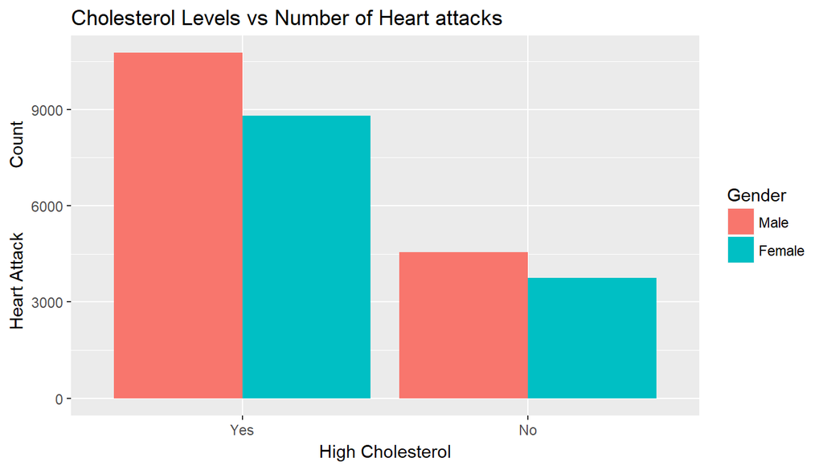

```r
ggplot(data = rData, aes(x=rData$toldhi2,y=rData$n,fill=rData$sex))+
  geom_bar(stat = "identity",position="dodge")+
  labs(title='Cholesterol Levels vs Number of Heart attacks',x='High Cholesterol',y='Heart Attack             Count',fill='Gender')
```

**Conclusion:** Visulaized Data shows that Males have higher heart attact count than females, irrespective of whether they have been told of High Blood Cholesterol.

**Research quesion 2:**

Do Veterans, suffer from sleep disorder and depressive disorder?

```r
rData<-brfss2013%>%
  select(veteran3,addepev2,sleptim1)%>%
  filter(sleptim1!='NA'&veteran3!='NA'&addepev2!='NA')%>%
  group_by(veteran3,addepev2)%>%
  summarise(count_dep=n(),Average_SleepTime=mean(sleptim1))
```

**Data Handling:** The sleep time, Depressive Disorder is obtained for both veterans and others and average sleep time and number of veterans sufferning from Depressive Disorder is calculated.

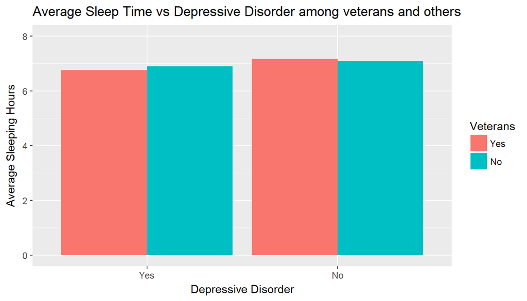

```r
ggplot(data = rData, aes(x=rData$addepev2,y=rData$Average_SleepTime,fill=rData$veteran3))+
  geom_bar(stat = "identity",position="dodge")+
  labs(title='Average Sleep Time vs Depressive Disorder among veterans and others',
  x='Depressive Disorder',y='Average Sleeping Hours',fill='Veterans')+
  scale_y_continuous(limit = c(0, 8))
```

**Conclusion:** The Graphs show very little difference between average sleeping hours of veterans and others, irrespective of whether the subject suffers from Depressive disorder.

**Research quesion 3:**

Do Education and financial status play role in overall health condtion?

```r
rData<-brfss2013%>%
  select(educa,income2,genhlth)%>%
  filter(educa!='NA'&income2!='NA'&genhlth!='NA'&educa!='Grades 9 though 11 (Some high school)')%>%
  group_by(income2,genhlth,educa)%>%
  summarise(count=n())
```

**Data Handling:** The education,income levels and general health status is selected and their count is calculated.Few grades are neglected to reduce data size.

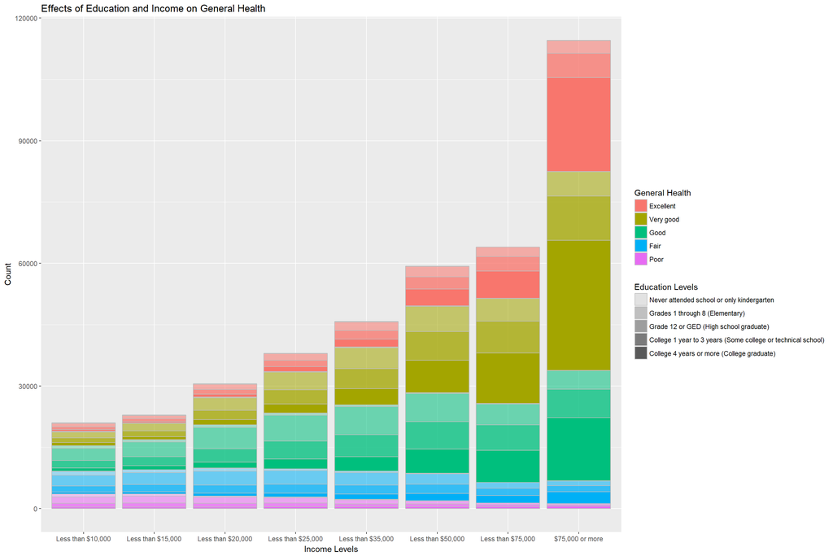

```r
ggplot(rData, aes(income2, count)) +
  geom_bar(aes(fill =genhlth,alpha=educa),  stat="identity", colour="grey")+
  labs(title = "Effects of Education and Income on General Health ",
  x = "Income Levels", y = "Count" ,fill='General Health',alpha='Education Levels')
```

**Conclusion:** Higher Income and Higher education shows excellent heath condition and health condition decreases as income and education level decreases.

**Research Summary:**While some questions can be answered with high level of confidence after cleaning the data and visualizing, many observations cannot be generalized to other population, because of various biases involved. One bias that was noticed was, survey had higher number of college graduates and people having higher income levels, who might obviously have high standard of living which infact contributes to high health levels.